# Part II - San Francisco Bay Area Bike System Exploration

## by Ukachi Agnes Eze-Mbey

## Investigation Overview

To draw insights from the data, I made use of the three (3) different levels of visualizations:

a. univariate, by the way of histograms (for numerical variables), pie charts, and bar charts (for qualitative factors)

b. bivariate, in form of scatter plots, clustered bar charts, and box plots to see the relationship between two sets of variables

c. multivariate plots, such as adapted heatmaps, clusterd bar charts and a correlation matrix

## Dataset Overview

> The dataset analyzed includes information about individual rides made in a bike-sharing system covering the greater San Francisco Bay area. It contains start and end station of the bikes, start and end time of sharing, information on whether the user is a customer or susbcriber to the system, member gender and year of birth.

## Visualization 1

User type ratio: 90.5% of the users are subscribers while less than than 10% are customers

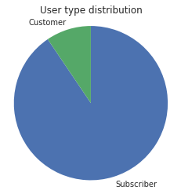

## Visualization 2

Gender Distribution: 23.3% of the users are female, 74.6 % are male and 2.1% other

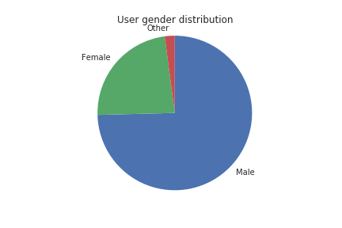

## Visualization 3

User-Gender Distribution: 91.2%(119007)of the male users are subscribers while 88.7%(36182) of the female users are subscribers

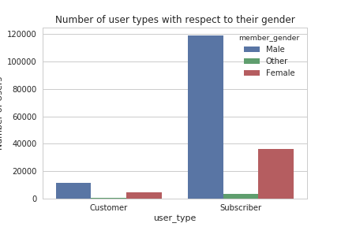